# CA-6

##### Mohammad Sadegh Aghili 810100274

## phase 1: data preprocessing

### Problems with Unbalanced Data in Clustering

Imbalance in the data can cause problems in the sorting process. In cases where the number of samples are from heterogeneous categories, clustering algorithms may pay more attention to samples from larger categories and ignore samples from smaller categories. This may cause clusters of unsustainable sizes and be careful to reduce them.

- The model might focus on the dominant class, and the minority classes may be poorly represented in the resulting clusters.
- If the number of samples of one category is much less than the other categories, the model may prefer towards larger categories and this will cause bias in the model.

#### Solutions for Handling Unbalanced Data in Clustering:

- Assign weights to different instances or clusters based on their class frequencies.
- Use oversampling (increasing the number of instances in the minority class) or undersampling (reducing the number of instances in the majority class) to balance the class distribution.

```python
import numpy as np
import pandas as pd
import seaborn as sns
from tqdm import tqdm
import matplotlib.pyplot as plt
from sklearn.decomposition import PCA
from sklearn.datasets import load_iris
from sklearn.cluster import KMeans, DBSCAN
from sklearn.metrics import silhouette_score
from sklearn.metrics import silhouette_samples
from sklearn.preprocessing import StandardScaler
from parsivar import Tokenizer, Normalizer, FindStems
from gensim.models.doc2vec import Doc2Vec, TaggedDocument
from sklearn.metrics import silhouette_score, homogeneity_score
```

```python
with open('persian.txt', 'r') as file:
    content = file.read()
    persian_stopwords = content.split()
```

```python
def preprocess_text(text):
    tokenizer = Tokenizer()
    tokens = tokenizer.tokenize_words(text)

    normalizer = Normalizer()
    normalized_tokens = [normalizer.normalize(token) for token in tokens]

    stemmer = FindStems()
    stemmed_tokens = [stemmer.convert_to_stem(token) for token in normalized_tokens]

    normalized_text = ' '.join(stemmed_tokens)

    return normalized_text
```

```python
def preprocess_text_with_stopwords(text):
    tokenizer = Tokenizer()
    tokens = tokenizer.tokenize_words(text)

    normalizer = Normalizer()
    normalized_tokens = [normalizer.normalize(token) for token in tokens]

    tokens_without_stopwords = [token for token in normalized_tokens if token not in persian_stopwords]

    stemmer = FindStems()
    stemmed_tokens = [stemmer.convert_to_stem(token) for token in tokens_without_stopwords]

    normalized_text = ' '.join(stemmed_tokens)

    return normalized_text
```

```python
train_data = pd.read_csv('train.csv', encoding='utf-8')

train_data['preprocessed_content'] = train_data['content'].apply(preprocess_text_with_stopwords)

train_data.to_csv('preprocessed_train_data.csv', index=False, encoding='utf-8')

print(train_data.head())
```

```
    label                                            content  \
0  فناوری  گزارش های منتشر شده حاکی از آن است که کاربران ...
1   ورزشی  سوپر استار سینما و از قهرمانان سابق ووشو ــ کو...
2   حوادث  مدیرعامل شرکت عمران آب کیش از فوت یک نفر در آت...
3  فناوری  یک نوجوان انگلیسی به اتهام هک حساب‌های کاربری ...
4   سلامت  دانشمندان در جدیدترین مطالعات خود اثرات جدید و...

                                preprocessed_content
0  گزارش منتشر حاکی کاربر تلگرام مناطقی جهان اروپ...
1  سوپر استار سینما قهرمان ووشو  کونگ‌فو حضور شهر...
2  مدیرعامل شرکت عمران آب کیش فوت نفر آتش‌سوزی با...
3  نوجوان انگلیسی اتهام هک حساب کاربری ایمیل تلفن...
4  دانشمند جدید مطالعات اثرات ویروس کرونا گوش کشف...
```

```python
test_data = pd.read_csv('test.csv', encoding='utf-8')

test_data['preprocessed_content'] = test_data['content'].apply(preprocess_text_with_stopwords)

test_data.to_csv('preprocessed_test_data.csv', index=False, encoding='utf-8')

print(test_data.head())
```

```
         label                                            content  \
0       فناوری  بعد از اعلام لیست ۲۳ شرکت مجاز ثبت سفارش و ارا...
1  فرهنگی/هنری  یک استاد علم قرائت قرآن کریم، گفت: ریشه موسیقی...
2        حوادث  آتش سوزی های زنجیره ای جنگل های زاگرس در استان...
3       فناوری  استفاده از سرویس‌های iMassage یا Facetime محصو...
4        حوادث  دادستان عمومی و انقلاب یاسوج گفت: 10 میلیون دل...

                                preprocessed_content
0  لیست 23 شرکت مجاز ثبت سفارش ارائه فروش تلفن هم...
1  استاد علم قرائت قرآن کریم ، گفت : ریشه موسیقی ...
2  آتش سوخت&سوز زنجیره جنگل زاگرس استان ایلام کهگ...
3  سرویس iMassage Facetime محصولات شرکت اپل ، دلی...
4  دادستان عمومی انقلاب یاسوج گفت : 10 دلار جعلی ...
```

### stemming or lemmatization

#### Stemming:

- Stemming involves removing prefixes or suffixes from words to obtain their root form. The result (stem) may not necessarily be a valid word, but it aims to capture the core meaning of related words.
- Stemming is useful when the goal is to reduce words to a common base form, ignoring language semantics.
- for example:
  - Original: "running," "runner," "ran"
  - Stemmed: "run"

#### Lemmatization:

- Lemmatization involves reducing words to their base or dictionary form (lemma). Unlike stemming, lemmatization ensures that the resulting word is valid in the language.
- Lemmatization typically involves using a lexicon and morphological analysis to determine the base form of a word.
- It considers the part-of-speech (POS) of the word to generate the correct lemma.
- for example:
  - Original: "running," "runner," "ran"
  - Lemmatized: "run"

#### Choosing between Stemming and Lemmatization:

- Stemming is suitable for times when processing speed is important and high accuracy is not required.
- Lemmatization is suitable for cases where we need more precision in retrieving the meaning of words.

## Phase 2: Problem process

```python
# import sys
# !{sys.executable} -m pip install sklearn_extra
```

```python
train_data = pd.read_csv('preprocessed_train_data.csv', encoding='utf-8')

train_data['preprocessed_content'] = train_data['preprocessed_content'].fillna('')

tokenized_data = [text.split() for text in train_data['preprocessed_content']]

tagged_data = [TaggedDocument(words=doc, tags=[str(i)]) for i, doc in enumerate(tokenized_data)]

model = Doc2Vec(vector_size=100, window=5, min_count=1, workers=4, epochs=20)
model.build_vocab(tagged_data)
model.train(tagged_data, total_examples=model.corpus_count, epochs=model.epochs)

model.save('doc2vec_model')

model = Doc2Vec.load('doc2vec_model')
```

```python
tokenized_test_data = [text.split() for text in test_data['preprocessed_content']]
# tagged_test_data = [TaggedDocument(words=doc, tags=[str(i)]) for i, doc in enumerate(tokenized_test_data)]

train_vectors = [model.infer_vector(tokens) for tokens in tqdm(tokenized_data, desc="Infer vectors for training data")]
test_vectors = [model.infer_vector(tokens) for tokens in tqdm(tokenized_test_data, desc="Infer vectors for test data")]

train_features = pd.DataFrame(train_vectors)
test_features = pd.DataFrame(test_vectors)

train_features.to_csv('train_features.csv', index=False)
test_features.to_csv('test_features.csv', index=False)
```

### K-Means:

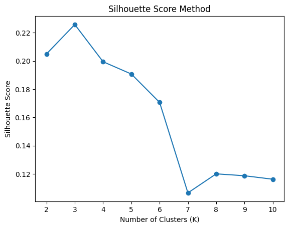

```python
silhouette_scores = []
k_values = range(2, 11)

for k in k_values:
    kmeans = KMeans(n_clusters=k, n_init=10, random_state=42)
    clusters = kmeans.fit_predict(train_features)
    silhouette_scores.append(silhouette_score(train_features, clusters))

plt.plot(k_values, silhouette_scores, marker='o')
plt.xlabel('Number of Clusters (K)')
plt.ylabel('Silhouette Score')
plt.title('Silhouette Score Method')
plt.show()
```

```
Silhouette Score (K-Means): 0.2258122394074289
```

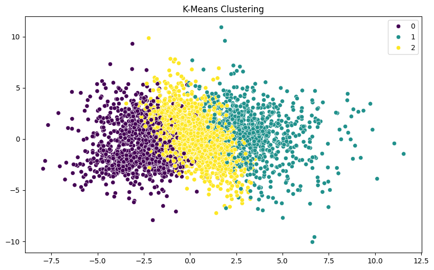

```python
K = 3
kmeans = KMeans(n_clusters=K, n_init=10, random_state=42)
train_clusters_kmeans = kmeans.fit_predict(train_features)
test_clusters_kmeans = kmeans.predict(test_features)

silhouette_kmeans = silhouette_score(train_features, train_clusters_kmeans)
print(f"Silhouette Score (K-Means): {silhouette_kmeans}")

pca = PCA(n_components=2)
train_pca = pca.fit_transform(train_features)

plt.figure(figsize=(10, 6))
sns.scatterplot(x=train_pca[:, 0], y=train_pca[:, 1], hue=train_clusters_kmeans, palette='viridis', legend='full')
plt.title('K-Means Clustering')
plt.show()
```

### DBSCAN:

```
Average Silhouette Score (DBSCAN): 0.9236767509266082
```

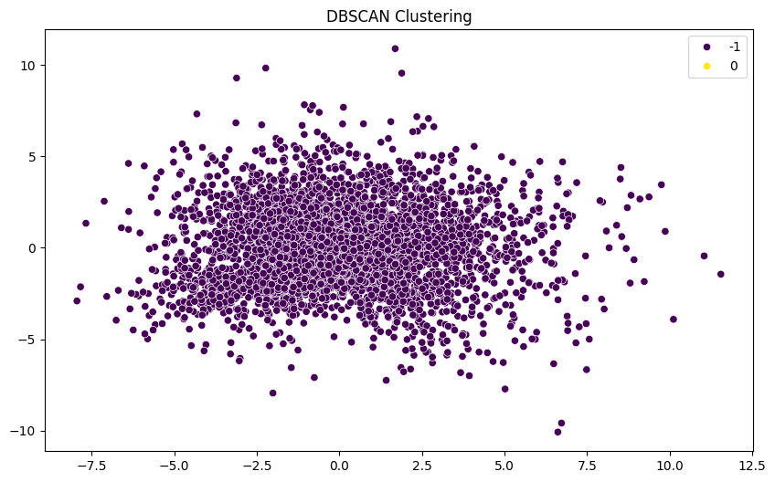

```python
dbscan = DBSCAN(eps=0.5, min_samples=6)
train_clusters_dbscan = dbscan.fit_predict(train_features)
test_clusters_dbscan = dbscan.fit_predict(test_features)

silhouette_dbscan = silhouette_samples(train_features, train_clusters_dbscan)
average_silhouette_dbscan = silhouette_dbscan[train_clusters_dbscan != -1].mean()
print(f"Average Silhouette Score (DBSCAN): {average_silhouette_dbscan}")

plt.figure(figsize=(10, 6))
sns.scatterplot(x=train_pca[:, 0], y=train_pca[:, 1], hue=train_clusters_dbscan, palette='viridis', legend='full')
plt.title('DBSCAN Clustering')
plt.show()
```

### 3.feature vector:

#### Representation of Data:

- Feature vectors serve as a compact and numerical representation of data points. They capture the essential characteristics of the data in a structured format.
- Features are the individual dimensions or attributes of the data that contribute to forming the feature vector.

#### Dimensionality Reduction:

- Feature vectors often serve as a means of reducing the dimensionality of the data. Instead of working with the original, potentially high-dimensional data, algorithms operate on feature vectors with a reduced number of dimensions.
- Dimensionality reduction can be crucial for computational efficiency and for avoiding the curse of dimensionality.

#### Compatibility with Machine Learning Libraries:

- Most machine learning libraries, including scikit-learn, TensorFlow, and PyTorch, expect input data in the form of feature vectors. Adhering to this standard allows for seamless integration with widely-used tools and libraries.

### 4.Explain of word2vec and doc2vec:

#### Word2Vec:

- Word Embedding: Learns continuous vector representations for words.
- Skip-gram and CBOW: Two architectures for predicting context words given a target word or vice versa.
- Training Process: Adjusts word vectors to maximize the likelihood of predicting context words based on co-occurrence patterns.
- Vector Representation: Each word is represented by a dense vector capturing semantic relationships.

#### Doc2Vec:

- Paragraph Vector (Doc2Vec): Extends Word2Vec to represent entire documents.
- DM and DBOW: Two architectures for predicting words or context in documents.
- Training Process: Adjusts vectors to maximize the likelihood of predicting words or context in the training data.
- Vector Representation: Each document is represented by a vector capturing its overall context and semantic relationships.

### 5.Pros and conse of DBSCAN and K-means :

#### k_MEAN:

- Choose K initial cluster centroids randomly or using a specific initialization method.
- Assign each data point to the nearest centroid, forming K clusters.
- Recalculate the centroids of each cluster based on the mean of the assigned points.
- Iterate between assignment and centroid update until convergence or a specified number of iterations.
- Advantages:
  - Simplicity: Simple and easy to implement.
  - Efficiency: Computationally efficient, especially for large datasets.
  - Scalability: Scales well with the number of data points.
- Disadvantages:
  - Sensitive to Initialization: Results can vary based on initial centroid placement.
  - Assumes Equal Variance: Assumes that clusters have similar variances, which may not be true for all datasets.
  - Requires Specifying K: The number of clusters (K) needs to be specified in advance.

#### DBSCAN:

- Identify core points that have a minimum number of points (MinPts) within a specified radius (Eps).
- Form clusters by connecting core points that are within each other's radius.
- Assign non-core points that are within the radius of a core point to the corresponding cluster.
- Points that do not belong to any cluster are considered noise.
- Advantages:
  - Handles Irregular Shapes: Can find clusters with irregular shapes and handle varying cluster densities.
  - No Need to Specify K: Automatically determines the number of clusters based on data density.
  - Robust to Outliers: Outliers do not affect the clustering significantly.
- Disadvantages:
  - Sensitive to Parameters: Sensitive to the choice of parameters (Eps and MinPts).
  - Not Deterministic: Results can vary based on the order of processing points.

#### Comparison:

- K-Means is Parametric: Requires specifying the number of clusters (K) in advance, while DBSCAN is non-parametric and automatically determines the number of clusters.
- Shape of Clusters: K-Means assumes spherical clusters and may struggle with irregular shapes, while DBSCAN can find clusters with various shapes.
- Handling Noise: DBSCAN is robust to noise and outliers, while K-Means is sensitive to outliers.
- Computational Complexity: K-Means is computationally efficient and scales well, whereas DBSCAN can be more computationally intensive, especially in high-dimensional spaces.

## Phase 3: Dimension reduction

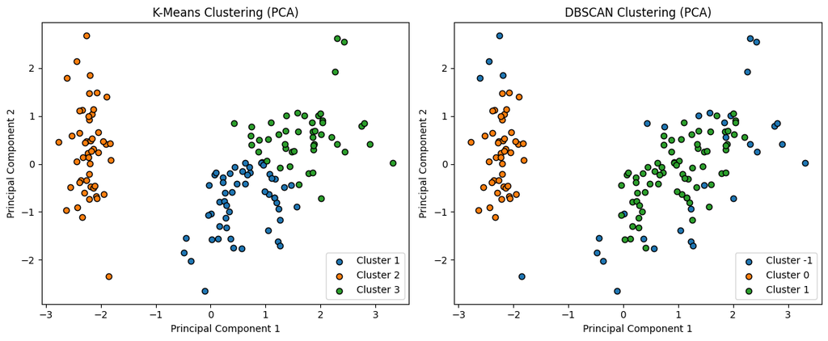

```python
iris = load_iris()
X = iris.data
y = iris.target

scaler = StandardScaler()
X_scaled = scaler.fit_transform(X)

kmeans = KMeans(n_clusters=3, n_init = 10, random_state=42)
y_kmeans = kmeans.fit_predict(X_scaled)

dbscan = DBSCAN(eps=0.5, min_samples=5)
y_dbscan = dbscan.fit_predict(X_scaled)

pca = PCA(n_components=2)
X_pca = pca.fit_transform(X_scaled)

plt.figure(figsize=(12, 5))

plt.subplot(1, 2, 1)
for cluster_label in np.unique(y_kmeans):
    plt.scatter(X_pca[y_kmeans == cluster_label, 0], X_pca[y_kmeans == cluster_label, 1],
                label=f'Cluster {cluster_label + 1}', edgecolors='k')

plt.title('K-Means Clustering (PCA)')
plt.xlabel('Principal Component 1')
plt.ylabel('Principal Component 2')
plt.legend()

plt.subplot(1, 2, 2)
for cluster_label in np.unique(y_dbscan):
    plt.scatter(X_pca[y_dbscan == cluster_label, 0], X_pca[y_dbscan == cluster_label, 1],
                label=f'Cluster {cluster_label}', edgecolors='k')

plt.title('DBSCAN Clustering (PCA)')
plt.xlabel('Principal Component 1')
plt.ylabel('Principal Component 2')
plt.legend()

plt.tight_layout()
plt.show()
```

### PCA (Principal Component Analysis):

PCA is a dimensionality reduction technique used to transform high-dimensional data into a lower-dimensional representation. It achieves this by identifying and extracting the most important features, called principal components, that capture the maximum variance in the data.

- Subtract the mean of each feature from every data point to center the data around the origin.
- Compute the covariance matrix to capture relationships between different features.
- Perform eigendecomposition on the covariance matrix to obtain eigenvectors and eigenvalues.
- Rank eigenvectors by their corresponding eigenvalues.
- Choose the top eigenvectors as principal components, representing new axes in the transformed space.
- Project the original data onto the selected principal components to create a lower-dimensional representation.

```python
silhouette_kmeans = silhouette_score(X_scaled, y_kmeans)
silhouette_dbscan = silhouette_score(X_scaled, y_dbscan)

print(f'Silhouette Score (K-Means): {silhouette_kmeans}')
print(f'Silhouette Score (DBSCAN): {silhouette_dbscan}')
```

```
Silhouette Score (K-Means): 0.45994823920518635
Silhouette Score (DBSCAN): 0.3565164814270073
```

## Evaluation and analysis

#### Silhouette Score:

The silhouette score is a measure of how similar an object is to its own cluster (cohesion) compared to other clusters (separation). It ranges from -1 to 1, where a high value indicates well-defined clusters.

- Calculate Cohesion (a):
  - For each data point, calculate the average distance to all other points in the same cluster. This represents how close the point is to the other points in its cluster.
- Calculate Separation (b):
  - For each data point, calculate the average distance to all points in the nearest cluster (different from the one the point belongs to). This represents how far the point is from points in the nearest other cluster.
- Calculate Silhouette Score (s):
  - For each data point, calculate the silhouette score using the formula: S = (b-a)/max(a,b)
  - Average the silhouette scores for all data points to get the overall score.

#### Homogeneity Score:

The homogeneity score measures the extent to which each cluster contains only members of a single class. It ranges from 0 to 1, where 1 indicates perfect homogeneity.

- ontingency Table:
  - Create a contingency table that represents the true class labels versus the assigned cluster labels.
- Calculate Homogeneity Score:
  - Use the contingency table to calculate the homogeneity score using the formula: H = 1 - (H(C|K)/H(C))
  - where H(C∣K) is the conditional entropy of the true classes given the assigned clusters, and H(C) is the entropy of the true classes.

```python
silhouette_kmeans = silhouette_score(X_scaled, y_kmeans)
silhouette_dbscan = silhouette_score(X_scaled, y_dbscan)

homogeneity_kmeans = homogeneity_score(y, y_kmeans)
homogeneity_dbscan = homogeneity_score(y, y_dbscan)

results_df = pd.DataFrame({
    'Method': ['K-Means', 'DBSCAN'],
    'Silhouette Score': [silhouette_kmeans, silhouette_dbscan],
    'Homogeneity Score': [homogeneity_kmeans, homogeneity_dbscan]
})

print(results_df)
```

```
    Method  Silhouette Score  Homogeneity Score
0  K-Means          0.459948           0.659127
1   DBSCAN          0.356516           0.500501
```

#### solutions to improve the performance

- Feature Scaling:
  - Ensure that your features are on the same scale. Use techniques like Min-Max scaling or Standardization (Z-score normalization) to make sure features contribute equally to the distance computations.
- Optimal Parameter Selection:
  - Tune the hyperparameters of your clustering algorithms. For example, in K-Means, experiment with different values of 'k' (number of clusters). In DBSCAN, adjust the 'eps' (radius) and 'min_samples' parameters.
- Dimensionality Reduction:
  - Apply dimensionality reduction techniques such as PCA before clustering. Reducing the number of dimensions can help focus on the most important features and improve algorithm performance.
- Data Preprocessing:
  - Clean and preprocess the data effectively. Handle missing values, outliers, and noisy data appropriately. Ensure that the data is in a suitable format for clustering.